# STATS 7022 - Data Science Bird Bath Analysis Assignment 2: Question 1

Max Glonek

Trimester 1, 2025

# 1 Load Libraries

# 2 Load Data

The data is contained within the file `bird_bath.rds`. The data is read in to `R`.

There are 161,057 rows in the `bird_bath` data.

# 3 Data Cleaning

## 3.1 Remove Missing Years

Some rows are missing a survey year (`survey_year`). These rows are removed from the data.

There are now 160,888 rows in the `bird_bath` data.

## 3.2 Identify the Top 15 Types of Bird

We consider only the top 15 bird species (`bird_type`) by frequency (`bird_count`). Results are summarised in Table 3.1.

Table 3.1: Top 15 birds at Australian bird baths, by frequency.

| bird_type | count |
| --- | --- |
| Noisy Miner | 292 |
| Australian Magpie | 262 |
| Rainbow Lorikeet | 235 |
| Red Wattlebird | 171 |
| Superb Fairy-wren | 170 |
| Magpie-lark | 160 |
| Pied Currawong | 157 |
| Crimson Rosella | 155 |
| Eastern Spinebill | 153 |
| Spotted Dove | 151 |
| Lewin’s Honeyeater | 133 |
| Satin Bowerbird | 131 |
| Crested Pigeon | 125 |
| Grey Fantail | 123 |
| Red-browed Finch | 117 |

There are now 14,280 rows in the `bird_bath` data.

## 3.3 Create the Response Variable

We define a new response variable, called `bird_present`, using the following rule:

- If `bird_count` is greater than zero for a row, then `bird_present` takes value “yes”,
- Otherwise, `bird_present` takes value “no”.

## 3.4 Select Columns

We only need the following columns:

- `urban_rural`
- `bird_type`
- `bird_present`

All other columns are removed.

## 3.5 Convert Variables to Categorical

We convert all remaining variables to categorical variables.

# 4 Models

We create two separate workflows using `tidymodels`:

1. A logistic regression model with `bird_present` as the response variable and `urban_rural` and `bird_type` as the predictors.

```
## ══ Workflow ════════════════════════════════════════════════════════════════════
## Preprocessor: Recipe
## Model: logistic_reg()
##
## ── Preprocessor ────────────────────────────────────────────────────────────────
## 1 Recipe Step
##
## • step_dummy()
##
## ── Model ───────────────────────────────────────────────────────────────────────
## Logistic Regression Model Specification (classification)
##
## Computational engine: glm
```

2. A logistic regression model with the same predictors and response, plus a two-way interaction between `urban_rural` and `bird_type`.

```
## ══ Workflow ════════════════════════════════════════════════════════════════════
## Preprocessor: Recipe
## Model: logistic_reg()
##
## ── Preprocessor ────────────────────────────────────────────────────────────────
## 2 Recipe Steps
##
## • step_dummy()
## • step_interact()
##
## ── Model ───────────────────────────────────────────────────────────────────────
## Logistic Regression Model Specification (classification)
##
## Computational engine: glm
```

Both models are fitted to the `bird_bath` data, with ROC curves displayed in Figure 5.1.

# 5 ROC Curves

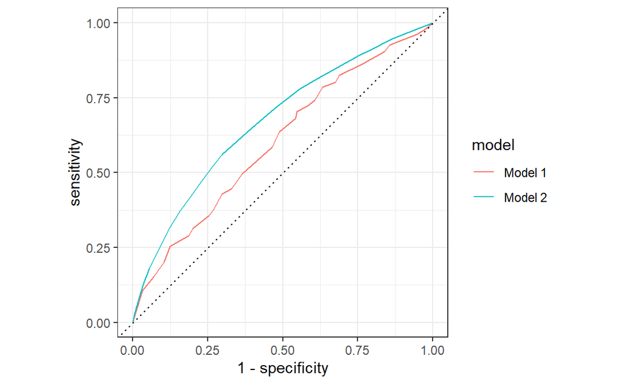

Figure 5.1: ROC curves for logisitic regression models.